# Exploratory Analysis

# Initial Thoughts

The original article has a strong narrative and contains lots of hard data. It compares the top 50 highest paying jobs between gender in Australia, and aims to highlight the disparity between genders.

- It has many numbers, but I feel visualisations of the data may have helped convey the size of the difference, as well as more easily summarising the differences across many job roles.

# Potential Paths

- What are the job roles with the biggest disparities?
- Are there any jobs where women earn more?
- If so, how many?
- Are there any jobs with roughly equal levels of pay (~ 10 %)
- Produce a visualisation showing the top 10 paying job roles, and the scale of the disparity between genders.

# Analysis

## Load Data

```r
summary(jobs)
```

```
  Gender Rank          Occupation           Gender           Individuals     Average Taxable Income $      X6
 Min.   :   1.0       Length:2197        Length:2197        Min.   :     3   Min.   : 13307           Length:2197
 1st Qu.: 275.0       Class :character   Class :character   1st Qu.:   209   1st Qu.: 38909           Class :character
 Median : 550.0       Mode  :character   Mode  :character   Median :   798   Median : 53850           Mode  :character
 Mean   : 549.8                                             Mean   :  4684   Mean   : 65678
 3rd Qu.: 824.0                                             3rd Qu.:  2960   3rd Qu.: 74441
 Max.   :1104.0                                             Max.   :293738   Max.   :577674
      X7                 X8                 X9
 Length:2197        Length:2197        Length:2197
 Class :character   Class :character   Class :character
 Mode  :character   Mode  :character   Mode  :character
```

## Are there any jobs where women earn more?

| GenderRankF | Occupation | GenderF | IndividualsF | AvgTaxIncomeF | GenderRankM | GenderM | IndividualsM | AvgTaxIncomeM | Difference |
| --- | --- | --- | --- | --- | --- | --- | --- | --- | --- |
| 73 | Mountain guide | Female | 8 | 99131 | 1032 | Male | 20 | 29760 | 69371 |
| 57 | Tennis player | Female | 4 | 105619 | 821 | Male | 10 | 44522 | 61097 |
| 43 | Paving plant operator | Female | 5 | 123281 | 406 | Male | 441 | 72243 | 51038 |
| 441 | Apprentice or trainee – autoglazier | Female | 3 | 54397 | 963 | Male | 138 | 35143 | 19254 |
| 99 | Excavator operator | Female | 50 | 88025 | 436 | Male | 5582 | 70210 | 17815 |
| 4 | Futures trader | Female | 28 | 281600 | 30 | Male | 281 | 264830 | 16770 |
| 81 | Bulldozer operator | Female | 6 | 94739 | 328 | Male | 517 | 78262 | 16477 |
| 8 | Magistrate | Female | 200 | 260161 | 35 | Male | 341 | 246737 | 13424 |
| 287 | Building insulation installer | Female | 18 | 63913 | 662 | Male | 1861 | 53280 | 10633 |
| 380 | Exhaust and muffler repairer | Female | 6 | 58216 | 727 | Male | 211 | 49411 | 8805 |
| 848 | Apprentice or trainee – bricklayer | Female | 5 | 34039 | 1077 | Male | 1220 | 25347 | 8692 |
| 114 | Master fisher | Female | 8 | 83428 | 360 | Male | 310 | 75589 | 7839 |
| 666 | Furniture packer; Furniture removalist – driver; Removalist | Female | 342 | 42623 | 962 | Male | 5662 | 35220 | 7403 |
| 572 | Apprentice or trainee – electrician | Female | 481 | 47354 | 893 | Male | 19182 | 40108 | 7246 |
| 89 | Earthmoving plant operator – general | Female | 1744 | 91602 | 267 | Male | 33474 | 84566 | 7036 |
| 436 | Miller – tyres; Tyre retreader | Female | 5 | 54795 | 752 | Male | 228 | 48067 | 6728 |
| 222 | Concrete mixer driver; Lorry driver; Semi-trailer driver; Transport driver; Truck driver – general | Female | 4179 | 68747 | 544 | Male | 143209 | 62350 | 6397 |
| 840 | Receptionist – general | Female | 62128 | 34360 | 1051 | Male | 1784 | 28089 | 6271 |
| 774 | Medical receptionist; Medical secretary | Female | 38305 | 37281 | 1019 | Male | 648 | 31012 | 6269 |
| 703 | Apprentice or trainee – information technology technician | Female | 55 | 40844 | 969 | Male | 316 | 34692 | 6152 |
| 628 | Fishing guide | Female | 7 | 44203 | 916 | Male | 127 | 38063 | 6140 |
| 877 | Apprentice or trainee – plasterer | Female | 5 | 32934 | 1059 | Male | 899 | 27431 | 5503 |
| 815 | Apprentice or trainee – canvas and leather tradesperson | Female | 3 | 35141 | 1027 | Male | 16 | 29980 | 5161 |
| 1032 | Dishwasher; Kitchen hand; Sandwich hand | Female | 45671 | 25404 | 1099 | Male | 36406 | 20427 | 4977 |
| 1066 | Apprentice or trainee – florist | Female | 127 | 22983 | 1103 | Male | 3 | 18100 | 4883 |
| 761 | Gymnast | Female | 9 | 38098 | 990 | Male | 9 | 33344 | 4754 |
| 671 | Apprentice or trainee – automotive electrician | Female | 44 | 42228 | 919 | Male | 968 | 37897 | 4331 |
| 1038 | Apprentice or trainee – beauty therapist | Female | 279 | 25066 | 1098 | Male | 6 | 20771 | 4295 |
| 607 | Bookkeeper; Registrar – school | Female | 35447 | 45248 | 879 | Male | 2788 | 41004 | 4244 |
| 991 | Child care worker – out of school hours care | Female | 4439 | 27884 | 1090 | Male | 821 | 23700 | 4184 |

[output cut: 51 more lines]

There are 81 occupations where women earn more than men, of a total 1092 where we have records for both genders.

By using an inner join, we’ve excluded jobs where we have no records for just one gender. * How many occupations have records for only one gender? * Of there, what is the balance? * Showing the difference is useful, but the difference as a percentage of the mean wage may be more insightful * Produce a plot to show the difference between jobs?

## Job roles with the biggest disparities

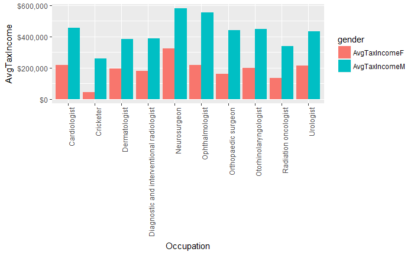

```r
wide_jobs %>%
  mutate(difference = AvgTaxIncomeM - AvgTaxIncomeF) %>%
  top_n(n = 10) %>%
  select(Occupation, AvgTaxIncomeF, AvgTaxIncomeM) %>%
  gather(key = gender, value = AvgTaxIncome, 2:3) %>%
  ggplot(aes(Occupation, AvgTaxIncome, fill = gender)) +
    geom_bar(stat = "identity", position = "dodge") +
    theme(axis.text.x = element_text(angle = 90, hjust = 1)) +
    scale_y_continuous(labels = scales::dollar)
```